# Week 4 Multiple Linear Regression

Lab 2 Socioeconomics and Exercise Behavior

Tony Lim

# 1. Overview

The paper “The economics of intense exercise” by Meltzer and Jena (*Journal of Health Economics*, 2010) specifies an model for exercise behavior. Individuals wish to maximize utility, which depends on health and other factors. Health depends on both exercise duration and intensity. Faced with a time budget constraint, the model posits that individuals with higher hourly wages will engage in more intense exercise because it is more time-efficient.

The goal of this analysis is to replicate the study using real survey data on exercise behavior and various demographic variables.

# 2. Data Collection

We will use the National Health and Nutrition Examination Survey (NHANES) for 3 periods: 1999-2000, 2001-2002, 2003-2004. After downloading the raw data and cleaning it (given in the script EconomicsExercise.R), we have a dataset NHANES.csv, which includes 13,876 observations and 11 variables:

- **SEQN:** Survey respondant’s sequence number
- **HOURS_TOTAL:** Total hours exercised in the last 30 days (NA if none)
- **INTENSITY_AVG:** Average intensity of exercise (metabolic equivalent) in the last 30 days (NA if none)
- **LN_HOURS:** Natural-log of hours exercised (NA if none)
- **LN_INTENSITY:** Natural-log of average intensity (NA if none)
- **ANY:** Dummy variable =1 for any exercise and =0 if none
- **INCOME:** Household income of respondant
- **RACE:** Race/ethnicity of respondant
- **AGE:** Age of respondant (years)
- **MARITAL:** Marital status of respondant
- **GENDER:** Biological sex of respondant

# 3. Data Exploration

Use `read.csv()` to load the NHANES data for analysis.

```r
list.of.packages <- c("tidyverse", "dplyr", "jtools", "foreign", "wesanderson")
new.packages <- list.of.packages[!(list.of.packages %in% installed.packages()[,"Package"])]
if(length(new.packages)) install.packages(new.packages)

library(tidyverse)
library(foreign)
library(wesanderson)
NHANES <- read.csv("NHANES.csv")
str(NHANES)
```

```
## 'data.frame':    13876 obs. of  11 variables:
##  $ SEQN         : int  5 7 12 14 15 16 25 34 45 55 ...
##  $ HOURS_TOTAL  : num  26.5 3.25 6 24 29.67 ...
##  $ INTENSITY_AVG: num  4.96 3.5 6 3.31 6.06 ...
##  $ LN_HOURS     : num  3.28 1.18 1.79 3.18 3.39 ...
##  $ LN_INTENSITY : num  1.6 1.25 1.79 1.2 1.8 ...
##  $ ANY          : int  1 1 1 1 1 1 1 1 1 1 ...
##  $ INCOME       : Factor w/ 6 levels "20k_45k","45k_75k",..: 3 NA 3 1 2 4 1 1 4 4 ...
##  $ RACE         : Factor w/ 4 levels "Black","Hispanic",..: 4 1 4 4 4 1 4 1 2 2 ...
##  $ AGE          : Factor w/ 7 levels "25_35","35_45",..: 3 4 2 6 2 6 2 2 1 4 ...
##  $ MARITAL      : Factor w/ 7 levels "Divorced","Living_Partner",..: 3 3 4 1 1 7 3 4 1 1 ...
##  $ GENDER       : Factor w/ 2 levels "Female","Male": 2 1 2 2 1 1 1 1 1 1 ...
```

## Question 1

What is the average number of hours exercised in the past 30 days among respondants reporting some activity? What is the maximum value? What are the characteristics of that individual?

```r
mean(NHANES$HOURS_TOTAL, na.rm = T)
```

```
## [1] 21.77589
```

```r
max(NHANES$HOURS_TOTAL, na.rm = T)
```

```
## [1] 562
```

```r
NHANES[which.max(NHANES$HOURS_TOTAL), ]
```

```
##       SEQN HOURS_TOTAL INTENSITY_AVG LN_HOURS LN_INTENSITY ANY  INCOME
## 2831 13293         562      6.640569 6.331502     1.893198   1 20k_45k
##       RACE   AGE  MARITAL GENDER
## 2831 White 25_35 Divorced   Male
```

# 4. Data Visualization

Next, let’s create a histogram of hours exercised by race/ethnicity. We will use ggplot to create 4 subplots using `facet_wrap()` with different colors.

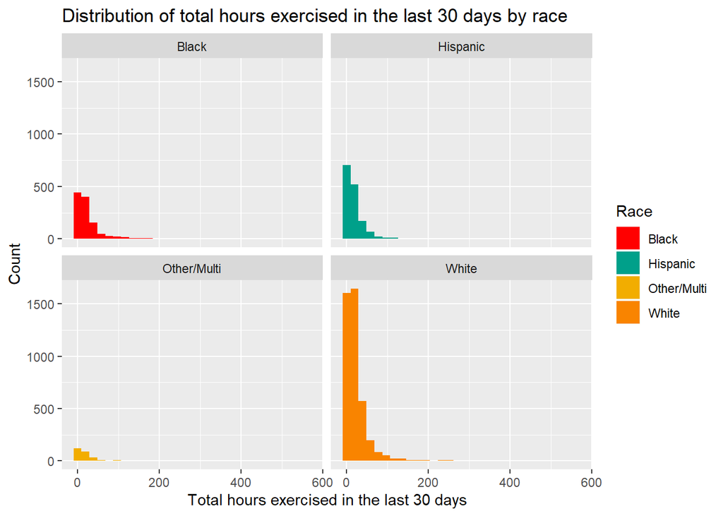

```r
library(ggplot2)
library(dplyr)
library(jtools)
NHANES %>%
  ggplot() +
  geom_histogram(mapping = aes(x = HOURS_TOTAL, fill = RACE)) +
  labs(title = "Distribution of total hours exercised in the last 30 days by race",
       x = "Total hours exercised in the last 30 days",
       y = "Count") +
  scale_fill_manual(name = "Race", values = wes_palette("Darjeeling1")) +
  facet_wrap(~ RACE)
```

Notice how the extreme exercise enthusiasts are making it difficult to see most of the data. Let’s adjust 2 things. First, let’s set `binwidth = 2` (this is an option inside `geom_histogram()`). Next, let’s cap the x-axis at 60 hours. We can achieve this by replacing `x = HOURS_TOTAL` with `x = ifelse(HOURS_TOTAL > 60, 60, HOURS_TOTAL)`. This works just like an if-else statment in Excel. It will lump anyone who reports exercising more than 60 hours into the 60 bin. Note, we are not changing the underlying data; this is just for graphical purposes.

## Question 2

Create a new histogram plot with `binwidth = 2` and x-axes capped at 60 hours.

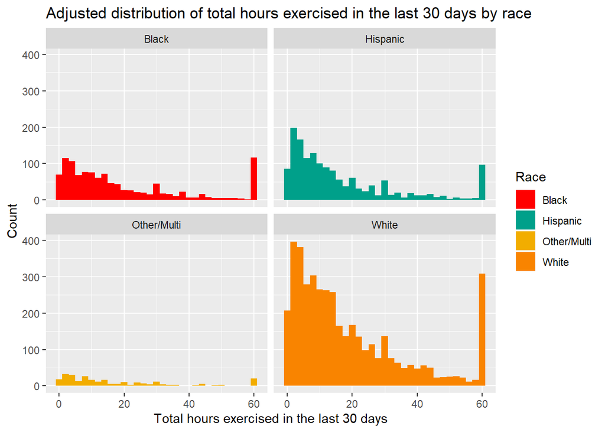

```r
NHANES %>%
  ggplot() +
  geom_histogram(mapping = aes(x = ifelse(HOURS_TOTAL > 60, 60, HOURS_TOTAL),
                               fill = RACE), binwidth = 2) +
  labs(title = "Adjusted distribution of total hours exercised in the last 30 days by race",
       x = "Total hours exercised in the last 30 days",
       y = "Count") +
  scale_fill_manual(name = "Race", values = wes_palette("Darjeeling1")) +
  facet_wrap(~ RACE)
```

## Question 3

Plot a histogram of average intensity by income bracket. Use `binwidth = 0.5`, and you do not need to cap the x-axis.

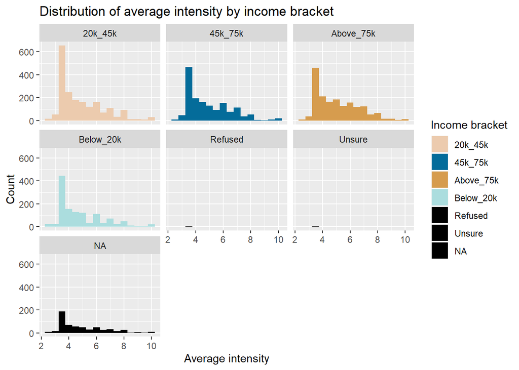

```r
inclab <- c("20-45K", "45-75K", "Above 75K", "Below 20K", "Refused", "Unsure", "NA")

NHANES %>%
  ggplot() +
  geom_histogram(mapping = aes(x = INTENSITY_AVG,
                               fill = INCOME), binwidth = 0.5) +
  labs(title = "Distribution of average intensity by income bracket",
       x = "Average intensity",
       y = "Count") +
  scale_fill_manual(name = "Income bracket",
                    values = c("#ECCBAE", "#046C9A", "#D69C4E",
                               "#ABDDDE", "#000000", "#000000"),
                    na.value = "black") +
  facet_wrap(~ INCOME)
```

## Question 4

Let’s repeat this, but further divide by gender. Hint: use `facet_grid()` instead of `facet_wrap()`.

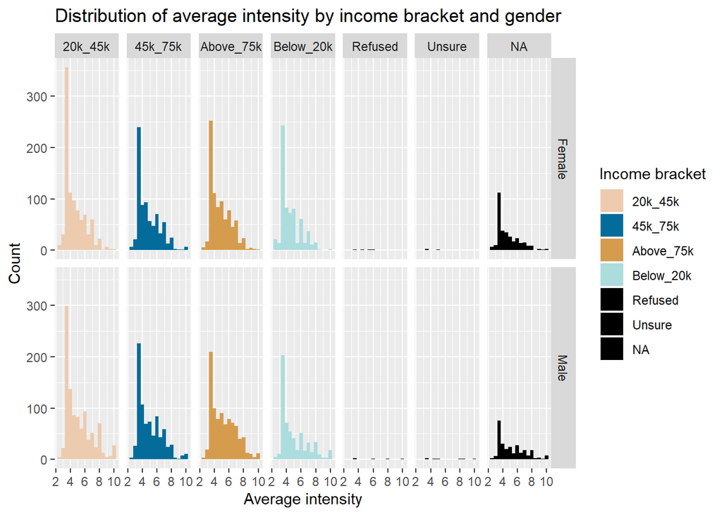

```r
NHANES %>%
  ggplot() +
  geom_histogram(mapping = aes(x = INTENSITY_AVG,
                               fill = INCOME), binwidth = 0.5) +
  labs(title = "Distribution of average intensity by income bracket and gender",
       x = "Average intensity",
       y = "Count") +
  scale_fill_manual(name = "Income bracket",
                    values = c("#ECCBAE", "#046C9A", "#D69C4E",
                               "#ABDDDE", "#000000", "#000000"),
                    na.value = "black") +
  facet_grid(cols = vars(INCOME), rows = vars(GENDER))
```

# 5. Linear Regression Analysis

When we just plot individual histograms, it can be difficult to ascertain what is going on, since many variables may be correlated. Multivariate regression can help us unpack the data, to see which relationships are statistically significant. First, let’s set our reference groups for each factor variable:

```r
# Select the reference group for each factor variable
NHANES$AGE <- relevel(NHANES$AGE, ref = "25_35")
NHANES$GENDER <- relevel(NHANES$GENDER, ref = "Female")
NHANES$MARITAL <- relevel(NHANES$MARITAL, ref = "Living_Partner")
NHANES$RACE <- relevel(NHANES$RACE, ref = "Hispanic")
NHANES$INCOME <- relevel(NHANES$INCOME, ref = "Below_20k")
```

## Question 5

Regress ANY exercise on age, marital status, race, gender, and income. How do you interpret the coefficients on the income variables?

```r
ols <- lm(ANY ~ AGE + MARITAL + RACE + GENDER + INCOME, data = NHANES)
summ(ols)
```

```
## MODEL INFO:
## Observations: 11990 (1886 missing obs. deleted)
## Dependent Variable: ANY
## Type: OLS linear regression
##
## MODEL FIT:
## F(21,11968) = 67.79, p = 0.00
## R² = 0.11
## Adj. R² = 0.10
##
## Standard errors: OLS
## ---------------------------------------------------------
##                               Est.   S.E.   t val.      p
## -------------------------- ------- ------ -------- ------
## (Intercept)                   0.37   0.02    15.25   0.00
## AGE35_45                     -0.05   0.01    -3.79   0.00
## AGE45_55                     -0.09   0.01    -6.15   0.00
## AGE55_65                     -0.13   0.02    -8.59   0.00
## AGE65_75                     -0.14   0.02    -8.71   0.00
## AGEAbove_75                  -0.23   0.02   -12.97   0.00
## AGEBelow_25                   0.03   0.03     0.76   0.44
## MARITALDivorced               0.08   0.02     3.33   0.00
## MARITALMarried                0.04   0.02     2.10   0.04
## MARITALNever_Married          0.08   0.02     3.20   0.00
## MARITALRefused               -0.16   0.19    -0.84   0.40
## MARITALUnsure                 0.53   0.47     1.13   0.26
## MARITALWidowed               -0.00   0.03    -0.06   0.95
## RACEBlack                    -0.01   0.01    -0.43   0.67
## RACEOther/Multi               0.09   0.02     3.70   0.00
## RACEWhite                     0.14   0.01    13.04   0.00
## GENDERMale                    0.05   0.01     5.95   0.00
## INCOME20k_45k                 0.08   0.01     7.10   0.00
## INCOME45k_75k                 0.18   0.01    13.45   0.00
## INCOMEAbove_75k               0.27   0.01    19.24   0.00
## INCOMERefused                -0.05   0.09    -0.53   0.60
## INCOMEUnsure                  0.01   0.09     0.17   0.87
## ---------------------------------------------------------
```

From the regression that set participants who earn below $20K as the reference group, we see that as income increases ($20-45K, $45-75K, above $75K), the coefficients also increase (0.08, 0.18, 0.27, respectively). Therefore, participants with more income are more likely to exercise.

Note, this is called a *linear probability model*. Even though the dependent variable is binary, we can run OLS to more easily interpret the results. We will see later how to run this as a logistic regression instead.

## Question 6

Regress total hours of exercise on age, marital status, race, gender, and income. How do your results compare to Meltzer and Jena (Table 3)? What might explain this?

```r
ols2 <- lm(HOURS_TOTAL ~ AGE + MARITAL + RACE + GENDER + INCOME, data = NHANES)
summ(ols2)
```

```
## MODEL INFO:
## Observations: 6371 (7505 missing obs. deleted)
## Dependent Variable: HOURS_TOTAL
## Type: OLS linear regression
##
## MODEL FIT:
## F(21,6349) = 6.66, p = 0.00
## R² = 0.02
## Adj. R² = 0.02
##
## Standard errors: OLS
## -----------------------------------------------------------
##                                Est.    S.E.   t val.      p
## -------------------------- -------- ------- -------- ------
## (Intercept)                   10.63    2.18     4.88   0.00
## AGE35_45                      -0.58    1.17    -0.50   0.62
## AGE45_55                       0.63    1.25     0.50   0.62
## AGE55_65                       3.35    1.33     2.51   0.01
## AGE65_75                       1.17    1.43     0.82   0.41
## AGEAbove_75                    1.40    1.67     0.84   0.40
## AGEBelow_25                    3.01    2.62     1.15   0.25
## MARITALDivorced                6.46    2.10     3.08   0.00
## MARITALMarried                 2.89    1.85     1.56   0.12
## MARITALNever_Married           6.96    2.09     3.34   0.00
## MARITALRefused                42.74   30.51     1.40   0.16
## MARITALUnsure                -18.36   30.52    -0.60   0.55
## MARITALWidowed                 0.90    2.44     0.37   0.71
## RACEBlack                      5.06    1.29     3.91   0.00
## RACEOther/Multi                2.94    2.15     1.37   0.17
## RACEWhite                      3.32    1.00     3.32   0.00
## GENDERMale                     6.78    0.78     8.65   0.00
## INCOME20k_45k                  0.44    1.14     0.39   0.70
## INCOME45k_75k                  0.23    1.24     0.19   0.85
## INCOMEAbove_75k                0.82    1.26     0.66   0.51
## INCOMERefused                 11.84   10.21     1.16   0.25
## INCOMEUnsure                  -7.35    9.24    -0.80   0.43
## -----------------------------------------------------------
```

```r
# ols3 <- lm(LN_HOURS ~ AGE + MARITAL + RACE + GENDER + INCOME, data = NHANES)
# summ(ols3)
```

The results from the regression do differ from Table 3 from Meltzer and Jena. Some possible explanations could be that our dataset included extra categories not included in the article’s dataset (e.g., included ages below 25, marital status of refused/unsure, race status of other/multi, and income status of refused/unsure). Our dataset had a sample size of 6,371 while the article’s dataset had a sample size of 6,135.

## Question 7

Regress average exercise intensity on age, marital status, race, gender, and income. Does this support the hypothesis that higher income individuals report more intense exercise?

```r
ols4 <- lm(INTENSITY_AVG ~ AGE + MARITAL + RACE + GENDER + INCOME, data = NHANES)
summ(ols4)
```

```
## MODEL INFO:
## Observations: 6371 (7505 missing obs. deleted)
## Dependent Variable: INTENSITY_AVG
## Type: OLS linear regression
##
## MODEL FIT:
## F(21,6349) = 39.90, p = 0.00
## R² = 0.12
## Adj. R² = 0.11
##
## Standard errors: OLS
## ---------------------------------------------------------
##                               Est.   S.E.   t val.      p
## -------------------------- ------- ------ -------- ------
## (Intercept)                   5.14   0.11    48.43   0.00
## AGE35_45                     -0.04   0.06    -0.77   0.44
## AGE45_55                     -0.40   0.06    -6.54   0.00
## AGE55_65                     -0.69   0.07   -10.65   0.00
## AGE65_75                     -0.86   0.07   -12.39   0.00
## AGEAbove_75                  -1.16   0.08   -14.24   0.00
## AGEBelow_25                   0.35   0.13     2.72   0.01
## MARITALDivorced               0.15   0.10     1.51   0.13
## MARITALMarried                0.15   0.09     1.63   0.10
## MARITALNever_Married          0.37   0.10     3.60   0.00
## MARITALRefused                1.17   1.49     0.79   0.43
## MARITALUnsure                -0.78   1.49    -0.52   0.60
## MARITALWidowed                0.19   0.12     1.57   0.12
## RACEBlack                    -0.23   0.06    -3.63   0.00
## RACEOther/Multi              -0.58   0.10    -5.55   0.00
## RACEWhite                    -0.44   0.05    -8.92   0.00
## GENDERMale                    0.47   0.04    12.20   0.00
## INCOME20k_45k                 0.01   0.06     0.27   0.79
## INCOME45k_75k                 0.00   0.06     0.00   1.00
## INCOMEAbove_75k               0.18   0.06     2.86   0.00
## INCOMERefused                 0.54   0.50     1.09   0.27
## INCOMEUnsure                  0.42   0.45     0.94   0.35
## ---------------------------------------------------------
```

```r
# ols5 <- lm(LN_INTENSITY ~ AGE + MARITAL + RACE + GENDER + INCOME, data = NHANES)
# summ(ols5)
```

The regression analysis does support the hypothesis that higher income individuals report more intense exercise. We see that respondants with an income above $75K have a coefficient value of 0.18 (p-value < 0.01). However, the coefficients for those earning $20-45K and $45-75K (0.01 and 0.00, respectively) were not statistically significant (p-values of 0.79 and 1.00, respectively).

# Bonus

Think about what might be driving these observed results. Use the following code to generate the following:

- **Table1**: Description of each activity and the number of respondants who report doing it at each METS intensity level, ranging form 2.5 to 10.
- **Histogram**: Number of respondents in each income bucket who report participating in each activity.

Which activities might drive these results?

```r
library(tidyr)
ACTIVITY <- read.csv("ACTIVITY.csv")
INNER <- inner_join(NHANES, ACTIVITY, by = "SEQN")
table1 <- table(INNER$DESCRIPTION, INNER$PADMETS)
table1
```

```
##
##                     2.5    3  3.5    4  4.5    5    6  6.5    7    8    9
##   AEROBICS            0    0    0    0    0  202    0    0  468    0    0
##   BASEBALL            0    0    0    0    0   75   22    0    0    0    0
##   BASKETBALL          0    0    0    0    0    0  115    0    0  357    0
##   BICYCLING           0    0    0  503    0    0    0    0    0  705    0
##   BOWLING             0  145    0    0    0    0    0    0    0    0    0
##   BOXING              0    0    0    0    0    0    1    0    0    0   23
##   CHEERLEADING        0    0    0    0    0    0    0    0    0    0    0
##   CHILDREN_GAMES      0    0    0    0    0    2    1    0    0    0    0
##   DANCE               0    0    0    0  729    0  120    0    0    0    0
##   FISHING             0    0  193    0    0    0   27    0    0    0    0
##   FOOTBALL            0    0    0    0    0   27    0    0    0   68    0
##   FRISBEE             0   39    0    0    0    0    0    0    0    6    0
##   GARDENING           0    0    0  244    0  196    0    0    0    0    0
##   GOLF                0    0  530    0   55    0    0    0    0    0    0
##   HIKING              0    0    0    0    0    0  242    0  287    0    0
##   HOCKEY              0    0    0    0    0    0    1    0    0   17    0
##   HORSEBACK_RIDING    0    0    0   35    0    0    0    4    0    0    0
##   HUNTING             0    0    0    0    0   61   19    0    0    0    0
##   JOGGING             0    0    0    0    0    0   85    0  319    0    0
##   KAYAKING            0    0   19    0    0    0    0    0   23    0    0
##   MARTIAL_ARTS        0    0    0   15    0    0    0    0    0    0    0
##   OTHER               0    0    0    0   22    0    0    0   29    0    0
##   PUSHUPS             0    0   29    0    0    0    0    0    0   71    0
##   RACQUETBALL         0    0    0    0    0    0    0    0    1    0    0
##   ROLLERBLADING       0    0    0    0    0    0   22    0   58    0    0
##   ROPE_JUMPING        0    0    0    0    0    0    0    0    0    2    0
##   ROWING              0    0   18    0    0    0    0    0   27    0    0
##   RUNNING             0    0    0    0    0    0    0    0   25    0    0
##   SITUPS              0    0   55    0    0    0    0    0    0   98    0
##   SKATEBOARDING       0    0    0    0    0    1    3    0    0    0    0
##   SKATING             0    0    0    0    0   16    0    0   33    0    0
##   SKIING_CROSS        0    0    0    0    0    0    0    0    3    0   45
##   SKIING_DOWNHILL     0    0    0    0    0    0    6    0    0   26    0
##   SOCCER              0    0    0    0    0    0   32    0    0    0    0
##   SOFTBALL            0    0    0    0    0   63   43    0    0    0    0
##   STAIRS              0    0    0    0    0    0  143    0    0  255    0
##   STRETCHING        505    0    0    0    0    0    0    0    0    0    0
##   SURFING             0    0    0    0    0    4    0    0    0    0    0
```

[output cut: 45 more lines]

```
##   SOCCER            122
##   SOFTBALL            0
##   STAIRS              0
##   STRETCHING          0
##   SURFING             0
##   SWIMMING            0
##   TENNIS              0
##   TRAMPOLINE          0
##   TREADMILL           0
##   VOLLEYBALL          0
##   WALKING             0
##   WEIGHTS             0
##   WRESTLING           0
##   YARDWORK            0
##   YOGA                0
```

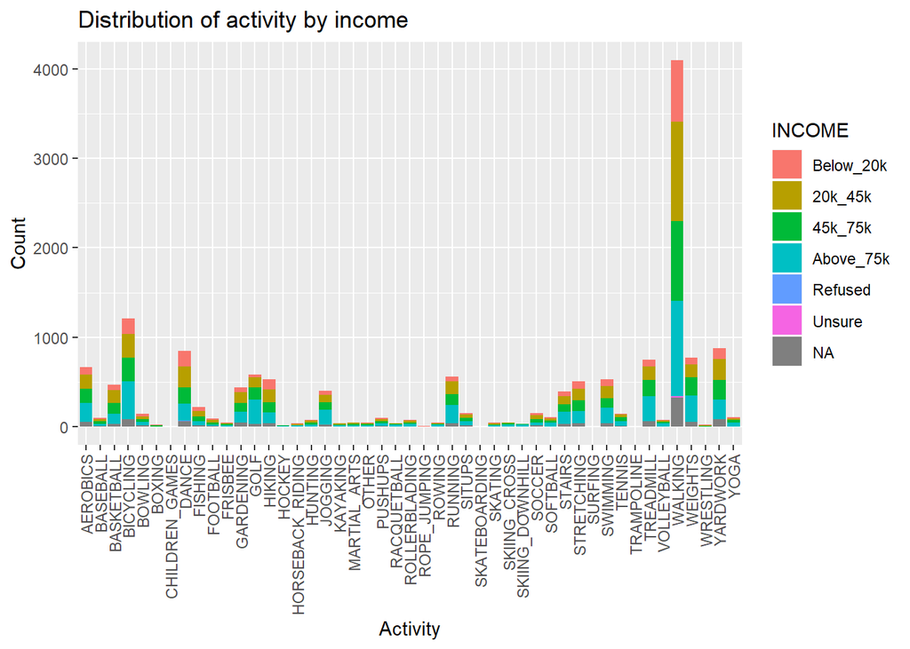

```r
INNER %>%
  ggplot() +
  geom_bar(aes(x = DESCRIPTION, fill = INCOME)) +
  theme(axis.text.x = element_text(angle = 90, hjust = 1, vjust = 0.5)) +
  labs(title = "Distribution of activity by income",
       x = "Activity",
       y = "Count")
```

Higher income respondants participated in more intense activities such as bicycling, jogging, swimming, and using the treadmill compared to their lower income counterparts. This may be due to wealthier individuals being more concerned and educated about their health. Also, wealthier individuals may be healthier in general, allowing them to participate in more intense exercises. Perhaps the built environment plays a role, and higher income individuals live in safer neighborhoods that allow for bicycling and jogging.